# Impact of borrowers profile and loan characteristics on the interest rate levels

## by Lauranne Kerkhove

## Investigation Overview

> In this investigation, I wanted to look at the impact of loan characteristics but also of a borrower's profile on the interest rate. Indeed, it is often said that you can obtain better interest rates based on your financial situation or based on how big of a loan you would apply for or on how risky is this loan based on what kind of category it is in.

## Dataset Overview

> There are 113,066 loans in the dataset. The attributes include 10 features out of which 5 features to describe the borrower's profile (Income Range, Employment Status, Employment Status Duration, Is Borrower Homeowner?, Total Credit Lines in the past 7 years) then Listing Creation Date, Borrower Rate (interest rate), Loan Category, Loan Original Amount and the Monthly Loan Payment.

## Distribution of loan's interest rates

The interest rate almost follows a normal distribution with the mean situated at around 19%. The interest rates are quite high in general with values oscillating between 0 and ±40%. The ditribution is slightly right skewed but, there is an isolated high peak at about 32%. There are very little loans lower than 5% or higher than 35%.

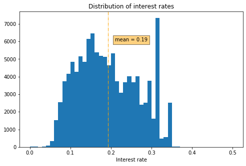

```python
# start with a standard-scaled plot
binsize = 0.01
bins = np.arange(0, df_loan['BorrowerRate'].max()+binsize, binsize)

plt.figure(figsize=[8, 5])
plt.hist(data = df_loan, x = 'BorrowerRate', bins = bins)
plt.xlabel('Interest rate')
plt.title('Distribution of interest rates')
plt.text(0.21, 6000, 'mean = 0.19', bbox=dict(facecolor='orange', alpha=0.5))
plt.axvline(df_loan['BorrowerRate'].mean(), color='orange', linestyle='-.', linewidth=1)
plt.show()
```

## Borrowers' profiles

A major part of the people are employed or full-time working and more likely homeowners. Only a few are self-employed and the rest are part-time, retired or under an unknown status of employment. The most common borrowers are in the ranges of 25K dollars to 75K dollars income, the second biggest group of borrowers earn more than 75k dollars and a minority of borrowers earn less than 25K dollars or nothing. Lastly, there is a bigger share of homeowners for borrowers earning 50K + dollars

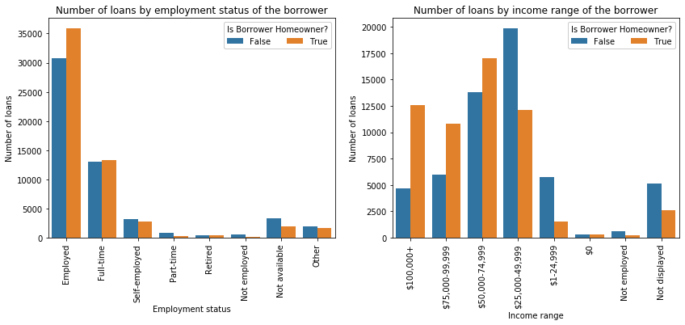

```python
# Plot clustered bar charts to evaluate relationship between categorical variables
plt.figure(figsize = [14, 5])


plt.subplot(1,2,1)
ax = sb.countplot(data = df_loan, x = 'EmploymentStatus', hue = 'IsBorrowerHomeowner')
ax.legend(loc = 1, ncol = 3, framealpha = 1, title = 'Is Borrower Homeowner?')
ax.set_title('Number of loans by employment status of the borrower')
ax.set_xlabel('Employment status')
ax.set_ylabel('Number of loans')

plt.xticks(rotation= 90)


plt.subplot(1,2,2)
ax = sb.countplot(data = df_loan, x = 'IncomeRange', hue = 'IsBorrowerHomeowner')
ax.legend(loc = 1, ncol = 3, framealpha = 1, title = 'Is Borrower Homeowner?')
ax.set_title('Number of loans by income range of the borrower')
ax.set_xlabel('Income range')
ax.set_ylabel('Number of loans')

plt.xticks(rotation= 90);
```

## Interest rate vs. borrower's profile features

As it can be expected employed borrowers have a lower interest rate than non-employed ones and on top of that if they are homeowner, they get an even lower rate. Unexpectedly, someone not employed but who is a homeowner is more likely to have a higher interest rate. Income range is a feature that has slight influence on the level of interest rate of a loan. As a general rule, the lower the income of a person, the higher is their loan interest rate. However, the income range at 0 dollars is getting a similar interest rate as average income range borrowers.

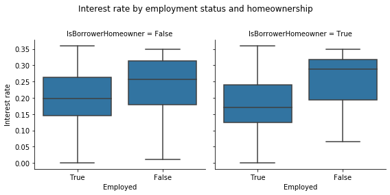

```python
# Create column employed vs. not employed
df_loan['Employed'] = df_loan['EmploymentStatus'].apply(lambda x: 'False' if x == "Not employed" else 'True')
# Boxplot 2 categorical variables (homeowner and employed) vs. Interest rate
g = sb.FacetGrid(data = df_loan, col = 'IsBorrowerHomeowner', height = 4)
g.map(sb.boxplot, 'Employed', 'BorrowerRate')
plt.subplots_adjust(top=0.8)
g.fig.suptitle('Interest rate by employment status and homeownership')
g.axes[0,0].set_ylabel('Interest rate');
```

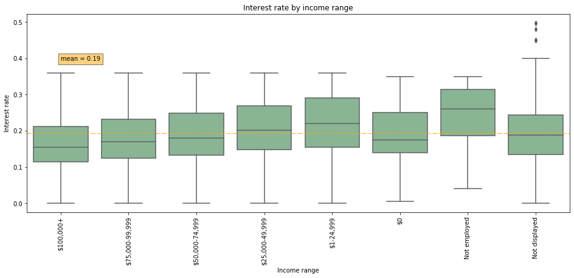

```python
# Plot boxplots to illustrate relationship between borrower's rate and categorical variables
plt.figure(figsize=(16, 6))

sb.boxplot(data = df_loan, x = 'IncomeRange', y = 'BorrowerRate', color = base_color)
plt.axhline(df_loan['BorrowerRate'].mean(), color='orange', linestyle='-.', linewidth=1)
plt.text(0, df_loan['BorrowerRate'].mean()+0.2, 'mean = 0.19', bbox=dict(facecolor='orange', alpha=0.5))
plt.xticks(rotation = 90)
plt.ylabel('Interest rate')
plt.xlabel('Income range')
plt.title('Interest rate by income range');
```

## Interest rate by loan amount and split by loan category

As the loan amount gets higher, the more likelihood to obtain an interest rate that is lower that the general average (19%).

There are categories for which we find less unemployed borrowers like Motorcycle, Boat, Baby and adoption and RV. Also we see that unemployed borrowers generally borrow for lower amounts. But what we notice is that the plotting pattern does not really vary much by category. Certainly some categories like cosmetic procedure and motorcycle do not have large loan amounts but the interest rate varies still from very low to very high. Mostly for small loans, the interest rate can be quite high. And as the loan amount increases, the max observed interest rate gets lower and lower. The interest rate despite the category can really be at a high or low level as well as the loan amount can be.

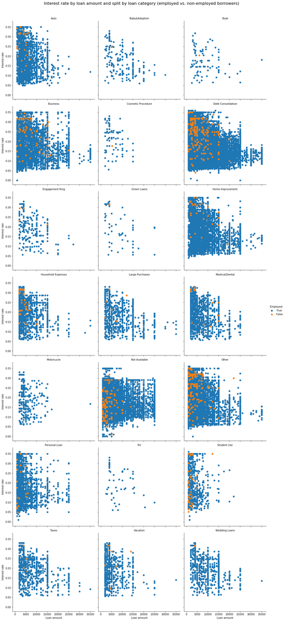

```python
# Scatter plots of Loan amounts vs. interest rate (employed vs. non-employed)
#and also separate by loan category
g = sb.FacetGrid(data = df_loan, col='LoanCategory' , col_wrap=3, hue = 'Employed', height = 5)
g.map(plt.scatter, 'LoanOriginalAmount', 'BorrowerRate')
g.add_legend()
g.set_titles('{col_name}')
g.axes[0].set_ylabel('Interest rate')
g.axes[3].set_ylabel('Interest rate')
g.axes[6].set_ylabel('Interest rate')
g.axes[9].set_ylabel('Interest rate')
g.axes[12].set_ylabel('Interest rate')
g.axes[15].set_ylabel('Interest rate')
g.axes[18].set_ylabel('Interest rate')
g.axes[18].set_xlabel('Loan amount')
g.axes[19].set_xlabel('Loan amount')
g.axes[20].set_xlabel('Loan amount')
plt.subplots_adjust(top=0.95)
g.fig.suptitle('Interest rate by loan amount and split by loan category (employed vs. non-employed borrowers)', fontsize=16);
```